# Workflow Data Wrangling

Bruce Hartman

University of St. Francis

2026-08-15 Revised 2026-10-11T09:14:30

Abstract

We present some techniques for manipulating data using `tidymodels` modeling workflow.

# Introduction

This notebook is designed to show how to use `tidymodels` workflow to wrangle your data for modeling.

Lots of times we do this before we start to model. We often do it in R (or even older fashioned, try to do it in Excel!) so our work is dependent on our R coding techniques. Such things as renaming columns, making categorical data into factors, scaling data to be normal with mean 0 and sd 1, or transforming variables rely on our R code.

With `tidymodels` we can do some of this wrangling right in the recipe step, without touching our starting data itself.

# Packages

We use the standard packages and `tidymodels`.

```r
library(ISLR2)
if(!("mbadtools" %in% installed.packages()))  pak::pak("bhartman2/mbadtools")
library(mbadtools, quietly = TRUE) # some extra ggplot functions
```

# Data

We obtained a large and curious dataset from Kaggle, with over 2 million records, and reduced it in size to something manageable by reading 200 rows.

```r
library(readr)
tictoc::tic("Time to Read Data")
airline_200 <- read_csv("airline_2m.csv", n_max=200)
tictoc::toc()
```

```
Time to Read Data: 0.58 sec elapsed
```

```r
airline_200 %>% skim_without_charts()
```

```
── Data Summary ────────────────────────
                           Values
Name                       Piped data
Number of rows             200
Number of columns          109
_______________________
Column type frequency:
  character                22
  Date                     1
  logical                  47
  numeric                  39
________________________
Group variables            None
```

|  | skim_variable | n_missing | complete_rate | min | max | empty | n_unique | whitespace |
| --- | --- | --- | --- | --- | --- | --- | --- | --- |
| 1 | Reporting_Airline | 0 | 1.000 | 2 | 2 | 0 | 25 | 0 |
| 2 | IATA_CODE_Reporting_Airline | 0 | 1.000 | 2 | 2 | 0 | 27 | 0 |
| 3 | Tail_Number | 36 | 0.820 | 4 | 6 | 0 | 163 | 0 |
| 4 | Origin | 0 | 1.000 | 3 | 3 | 0 | 72 | 0 |
| 5 | OriginCityName | 0 | 1.000 | 9 | 28 | 0 | 70 | 0 |
| 6 | OriginState | 0 | 1.000 | 2 | 2 | 0 | 36 | 0 |
| 7 | OriginStateFips | 0 | 1.000 | 2 | 2 | 0 | 36 | 0 |
| 8 | OriginStateName | 0 | 1.000 | 4 | 14 | 0 | 36 | 0 |
| 9 | Dest | 0 | 1.000 | 3 | 3 | 0 | 72 | 0 |
| 10 | DestCityName | 0 | 1.000 | 8 | 28 | 0 | 68 | 0 |

[output cut: 12 more lines]

|  | skim_variable | n_missing | complete_rate | min | max | median | n_unique |
| --- | --- | --- | --- | --- | --- | --- | --- |
| 1 | FlightDate | 0 | 1 | 1988-04-04 | 2020-03-24 | 2005-11-22 | 199 |

|  | skim_variable | n_missing | complete_rate | mean | count |
| --- | --- | --- | --- | --- | --- |
| 1 | FirstDepTime | 200 | 0 | NaN | : |
| 2 | TotalAddGTime | 200 | 0 | NaN | : |
| 3 | LongestAddGTime | 200 | 0 | NaN | : |
| 4 | DivReachedDest | 200 | 0 | NaN | : |
| 5 | DivActualElapsedTime | 200 | 0 | NaN | : |
| 6 | DivArrDelay | 200 | 0 | NaN | : |
| 7 | DivDistance | 200 | 0 | NaN | : |
| 8 | Div1Airport | 200 | 0 | NaN | : |
| 9 | Div1AirportID | 200 | 0 | NaN | : |
| 10 | Div1AirportSeqID | 200 | 0 | NaN | : |

[output cut: 37 more lines]

|  | skim_variable | n_missing | complete_rate | mean | sd | p0 | p25 | p50 | p75 | p100 |
| --- | --- | --- | --- | --- | --- | --- | --- | --- | --- | --- |
| 1 | Year | 0 | 1.000 | 2.005065e+03 | 9.004230e+00 | 1988 | 1997.0 | 2005.0 | 2013.00 | 2020 |
| 2 | Quarter | 0 | 1.000 | 2.410000e+00 | 1.103626e+00 | 1 | 1.0 | 2.0 | 3.00 | 4 |
| 3 | Month | 0 | 1.000 | 6.355000e+00 | 3.392124e+00 | 1 | 3.0 | 6.0 | 9.00 | 12 |
| 4 | DayofMonth | 0 | 1.000 | 1.619000e+01 | 9.195471e+00 | 1 | 8.0 | 16.0 | 24.00 | 31 |
| 5 | DayOfWeek | 0 | 1.000 | 3.795000e+00 | 1.960149e+00 | 1 | 2.0 | 4.0 | 5.00 | 7 |
| 6 | DOT_ID_Reporting_Airline | 0 | 1.000 | 1.988874e+04 | 3.616751e+02 | 19386 | 19704.0 | 19805.0 | 20304.00 | 20452 |
| 7 | Flight_Number_Reporting_Airline | 0 | 1.000 | 1.859165e+03 | 1.835089e+03 | 1 | 546.5 | 1246.0 | 2284.75 | 7659 |
| 8 | OriginAirportID | 0 | 1.000 | 1.279047e+04 | 1.584274e+03 | 10140 | 11298.0 | 12892.0 | 14107.00 | 16440 |
| 9 | OriginAirportSeqID | 0 | 1.000 | 1.279048e+06 | 1.584270e+05 | 1014002 | 1129802.0 | 1289201.0 | 1410701.00 | 1644001 |
| 10 | OriginCityMarketID | 0 | 1.000 | 3.173902e+04 | 1.376020e+03 | 30140 | 30529.0 | 31295.0 | 32575.00 | 35096 |

[output cut: 29 more lines]

# Data Wrangling

What do we notice about this data? There are 200 rows and 109 columns.

- Some numeric columns have almost zero variance
- Some columns have lots of missing values:
  - 197 for `CancellationCode`, a character variable
  - 200 for all 47 of the logical variables, that is all of the rows!
  - 171 for a whole series of 5 numeric variables;
  - 127 for `DivAirportLandings`
- Some numeric variables are highly correlated; only one should be kept.
- Some numeric variables are really codes:
  - 1-15 in the numeric skim, and many others.

```r
airline_200 %>% skim_without_charts(Cancelled)
```

```
── Data Summary ────────────────────────
                           Values
Name                       Piped data
Number of rows             200
Number of columns          109
_______________________
Column type frequency:
  numeric                  1
________________________
Group variables            None
```

|  | skim_variable | n_missing | complete_rate | mean | sd | p0 | p25 | p50 | p75 | p100 |
| --- | --- | --- | --- | --- | --- | --- | --- | --- | --- | --- |
| 1 | Cancelled | 0 | 1 | 0.025 | 0.1565167 | 0 | 0 | 0 | 0 | 1 |

```r
airline_200 %>% select(Cancelled) %>% summarize(n=n(), .by=Cancelled)
```

| Cancelled | n |
| --- | --- |
| 0 | 195 |
| 1 | 5 |

- `Cancelled` is numeric and an indicator, but it is sparse, so its removal depends on the cut point chosen– what frequency of nonzero values needs be present to include it?
  - 0.975 is 97.5%.

We ought to eliminate the columns that have over 100 missing values, and those with zero variance. We also should put in a cut that leaves `Cancelled` in, as it could be important.

# Correlated Variables

We could plan to remove some variables based on similar meanings.

```r
airline_200 %>% select(Distance, DistanceGroup) %>% cor
```

```
               Distance DistanceGroup
Distance      1.0000000     0.9676352
DistanceGroup 0.9676352     1.0000000
```

```r
airline_200 %>% select(ArrDelay,ArrDelayMinutes, ArrivalDelayGroups) %>% cor
```

```
                   ArrDelay ArrDelayMinutes ArrivalDelayGroups
ArrDelay                  1              NA                 NA
ArrDelayMinutes          NA               1                 NA
ArrivalDelayGroups       NA              NA                  1
```

```r
airline_200 %>% select(DestAirportID,DestAirportSeqID) %>% cor
```

```
                 DestAirportID DestAirportSeqID
DestAirportID                1                1
DestAirportSeqID             1                1
```

```r
airline_200 %>% select(DestAirportID,DestAirportSeqID) %>% cor
```

```
                 DestAirportID DestAirportSeqID
DestAirportID                1                1
DestAirportSeqID             1                1
```

`ArrDelay`, `ArrDelayMinutes`,are related because the first contains negative entries, for early, and the second zeroes them out. `ArrivalDelayGroups` is a classification.

`Distance`, `DistanceGroup` are highly correlated; the second is a classification assigned based on the mileage in the first.

`DestAirportID`, `DestAirportSeqID` are 100% correlated. One contains the other. As a numeric variable they enter wrongly into the calculation.

Some of the codes at least should be converted to factors, but we won’t do that.

# Wrangling with `dplyr`

The non-workflow way to handle this is with `dplyr`.

```r
airline_200 %>% skim %>% summary
```

```
── Data Summary ────────────────────────
                           Values
Name                       Piped data
Number of rows             200
Number of columns          109
_______________________
Column type frequency:
  character                22
  Date                     1
  logical                  47
  numeric                  39
________________________
Group variables            None
```

For zero variance, we keep numeric cols with sd > .000001, essentially 0:

```r
HSD = airline_200 %>% skim %>%
  filter(numeric.sd <=.000001) %>%
  pull(skim_variable)
HSD
```

```
[1] "Diverted"           "Flights"            "WeatherDelay"
[4] "SecurityDelay"      "DivAirportLandings"
```

```r
airline_200_1= airline_200 %>% select(-HSD)
airline_200_1 %>% skim %>% summary()
```

```
── Data Summary ────────────────────────
                           Values
Name                       Piped data
Number of rows             200
Number of columns          104
_______________________
Column type frequency:
  character                22
  Date                     1
  logical                  47
  numeric                  34
________________________
Group variables            None
```

For the few numeric columns with large numbers of missing values:

```r
FMV = airline_200_1 %>% skim %>% yank("numeric") %>%
  filter(n_missing >= 80) %>%
  pull(skim_variable)
FMV
```

```
[1] "CarrierDelay"      "NASDelay"          "LateAircraftDelay"
```

```r
airline_200_2= airline_200_1 %>% select(-FMV)
airline_200_2 %>% skim %>% summary
```

```
── Data Summary ────────────────────────
                           Values
Name                       Piped data
Number of rows             200
Number of columns          101
_______________________
Column type frequency:
  character                22
  Date                     1
  logical                  47
  numeric                  31
________________________
Group variables            None
```

Remove the correlated variables, and all the logical variables, which are all missing values.

```r
airline_200_3 = airline_200_2 %>%
  select(-ArrDelayMinutes, -ArrivalDelayGroups,
         -DistanceGroup, -DestAirportSeqID) %>%
  select(-where(is.logical),
         -where(is.factor),
         -where(is.Date),
         -where(is.character)
         )

airline_200_3 %>% skim %>% summary
```

```
── Data Summary ────────────────────────
                           Values
Name                       Piped data
Number of rows             200
Number of columns          27
_______________________
Column type frequency:
  numeric                  27
________________________
Group variables            None
```

```r
airline_200_3 %>% names
```

```
 [1] "Year"                            "Quarter"
 [3] "Month"                           "DayofMonth"
 [5] "DayOfWeek"                       "DOT_ID_Reporting_Airline"
 [7] "Flight_Number_Reporting_Airline" "OriginAirportID"
 [9] "OriginAirportSeqID"              "OriginCityMarketID"
[11] "OriginWac"                       "DestAirportID"
[13] "DestCityMarketID"                "DestWac"
[15] "DepDelay"                        "DepDelayMinutes"
[17] "DepDel15"                        "DepartureDelayGroups"
[19] "TaxiOut"                         "TaxiIn"
[21] "ArrDelay"                        "ArrDel15"
[23] "Cancelled"                       "CRSElapsedTime"
[25] "ActualElapsedTime"               "AirTime"
[27] "Distance"
```

27 columns remain.

# Wrangling with `tidymodels`

Start with a basic recipe defining the model formula and dataset. The dataset is not a permanent choice; it just has to have all the column names in it.

## Recipe

```r
airline_recipe_basic <- recipe(ActualElapsedTime ~ ., data = airline_200)
```

## Preprocess

Modify the recipe by preprocessing steps:

To match the `dplyr` output we need to include `Cancelled`. It is a 0/1 variable with few 1’s. For that reason we modify the non-zero-variance first step with ‘freq_cut = 98/2’, rather than the default 95/5.

```r
airline_rec3 <- airline_recipe_basic %>%
  # remove numeric predictors with close to zero variance or more than 98% a single value
  step_nzv(all_numeric_predictors(), freq_cut = 98/2) %>%
  # remove cols with missing valuess over .4 *200
  step_filter_missing(all_numeric_predictors(), threshold=.4) %>%
  # remove logicals
  step_rm(all_logical_predictors()) %>%
  # remove factors
  step_rm(all_factor_predictors()) %>%
  # remove date column
  step_rm(all_date_predictors()) %>%
  # remove specific correlated columns
  step_rm(ArrDelayMinutes, ArrivalDelayGroups,
         DistanceGroup, DestAirportSeqID)
```

Which method is easier?

## Prep

Prep the data with the revised recipe; this shows what is being done at each step, as a check.

```r
pr3 <- prep(airline_rec3, training=airline_200,
           verbose=TRUE, log_changes=TRUE, fresh=TRUE)
```

```
oper 1 step nzv [training]
step_nzv (nzv_M0loF):
 removed (5): Diverted, Flights, WeatherDelay, SecurityDelay, ...

oper 2 step filter missing [training]
step_filter_missing (filter_missing_sJnqQ):
 removed (3): CarrierDelay, NASDelay, LateAircraftDelay

oper 3 step rm [training]
step_rm (rm_zgPi9):
 removed (47): FirstDepTime, TotalAddGTime, LongestAddGTime, ...

oper 4 step rm [training]
step_rm (rm_4iCIh):
 removed (22): Reporting_Airline, IATA_CODE_Reporting_Airline, ...

oper 5 step rm [training]
step_rm (rm_eYA4B):
 removed (1): FlightDate

oper 6 step rm [training]
step_rm (rm_n1yzA):
 removed (4): DestAirportSeqID, ArrDelayMinutes, ...

The retained training set is ~ 0.05 Mb  in memory.
```

## Bake

Bake the prepped data into a dataframe for checking:

```r
bk3 = bake(pr3, new_data=airline_200)
bk3
```

| Year | Quarter | Month | DayofMonth | DayOfWeek | DOT_ID_Reporting_Airline | Flight_Number_Reporting_Airline | OriginAirportID | OriginAirportSeqID | OriginCityMarketID | OriginWac | DestAirportID | DestCityMarketID | DestWac | DepDelay | DepDelayMinutes | DepDel15 | DepartureDelayGroups | TaxiOut | TaxiIn | ArrDelay | ArrDel15 | Cancelled | CRSElapsedTime | AirTime | Distance | ActualElapsedTime |
| --- | --- | --- | --- | --- | --- | --- | --- | --- | --- | --- | --- | --- | --- | --- | --- | --- | --- | --- | --- | --- | --- | --- | --- | --- | --- | --- |
| 1998 | 1 | 1 | 2 | 5 | 19386 | 675 | 13487 | 1348701 | 31650 | 63 | 14869 | 34614 | 87 | 19 | 19 | 1 | 1 | 24 | 3 | 23 | 1 | 0 | 176 | 153 | 991 | 180 |
| 2009 | 2 | 5 | 28 | 4 | 20437 | 671 | 13342 | 1334202 | 33342 | 45 | 13204 | 31454 | 33 | -2 | 0 | 0 | -1 | 10 | 8 | 0 | 0 | 0 | 157 | 141 | 1066 | 159 |
| 2013 | 2 | 6 | 29 | 6 | 20398 | 3297 | 11921 | 1192102 | 31921 | 82 | 11298 | 30194 | 74 | 14 | 14 | 0 | 0 | 9 | 6 | -3 | 0 | 0 | 135 | 103 | 773 | 118 |
| 2010 | 3 | 8 | 31 | 2 | 19790 | 1806 | 12892 | 1289201 | 32575 | 91 | 11433 | 31295 | 43 | 0 | 0 | 0 | 0 | 23 | 7 | -20 | 0 | 0 | 270 | 220 | 1979 | 250 |
| 2006 | 1 | 1 | 15 | 7 | 20355 | 465 | 11618 | 1161801 | 31703 | 21 | 11057 | 31057 | 36 | 51 | 51 | 1 | 3 | 19 | 8 | 32 | 1 | 0 | 126 | 80 | 529 | 107 |
| 1995 | 4 | 11 | 29 | 3 | 19790 | 1198 | 11298 | 1129802 | 30194 | 74 | 14814 | 30476 | 72 | 0 | 0 | 0 | 0 | 29 | 5 | 11 | 0 | 0 | 51 | 28 | 190 | 62 |
| 2006 | 3 | 8 | 7 | 1 | 19704 | 1431 | 10721 | 1072101 | 30721 | 13 | 11042 | 30647 | 44 | -4 | 0 | 0 | -1 | 33 | 4 | 2 | 0 | 0 | 125 | 94 | 563 | 131 |
| 2019 | 2 | 6 | 11 | 2 | 20363 | 3459 | 10397 | 1039707 | 30397 | 34 | 10868 | 30868 | 37 | 221 | 221 | 1 | 12 | 19 | 6 | 214 | 1 | 0 | 67 | 35 | 192 | 60 |
| 2008 | 3 | 8 | 3 | 7 | 20378 | 7233 | 13930 | 1393001 | 30977 | 41 | 11042 | 30647 | 44 | 2 | 2 | 0 | 0 | 26 | 3 | 10 | 0 | 0 | 80 | 59 | 316 | 88 |
| 2018 | 1 | 2 | 8 | 4 | 19393 | 5932 | 13232 | 1323202 | 30977 | 41 | 11259 | 30194 | 74 | 16 | 16 | 1 | 1 | 34 | 5 | 29 | 1 | 0 | 140 | 114 | 793 | 153 |

[output cut: 190 more lines]

## Skim

```r
bk3 %>% skim %>% summary
```

```
── Data Summary ────────────────────────
                           Values
Name                       Piped data
Number of rows             200
Number of columns          27
_______________________
Column type frequency:
  numeric                  27
________________________
Group variables            None
```

27 columns remain, all numeric.

## Compare Columns

Check names of variables: `setequal()` easily checks that the sets of names match.

```r
setequal(airline_200_3 %>% names,
         bk3 %>% names)
```

```
[1] TRUE
```

# Model

We will use a `ranger` random forest model.

We specify ‘mtry’, ‘min_n’, and ‘trees’ parameters according to `ranger` documentation.

```r
rf_spec <- rand_forest(
  mode = "regression",
  mtry = 8,        # number of predictors sampled at each split
  min_n = 10,       # minimum data points in a node
  trees = 1000          # keep high for stability
) %>% set_engine("ranger", importance = "permutation", keep.inbag = TRUE)
```

# Workflow

Build the workflow.

```r
rf_workflow <- workflow() %>%
  add_model(rf_spec) %>%
  add_recipe(airline_rec3)
```

# Run Workflow

There are 5 missing values in the `airline_200` target column `ActualElapsedTime`. Random forest will not run with NA target values.

```r
# Filter out missing values in the target column
airline_clean <- airline_200 %>%
  filter(!is.na(ActualElapsedTime))
#Fit the workflow with clean data.
tictoc::tic()
rf_fit <- rf_workflow %>%
  fit(data = airline_clean)
tictoc::toc()
```

```
1.05 sec elapsed
```

# Predictions

On the clean data. Since we kept the ‘inbag’ in the random forest we can compute standard error `se` in the predictions. We then augment with the response and the lower and upper 95% ci values.

```r
rf_fit_obj = extract_fit_engine(rf_fit)
rf_pred <- predict(rf_fit_obj, airline_clean, type="se")
rf_aug <- data.frame(ActualElapsedTime =
                       airline_clean %>% pull(ActualElapsedTime),
                    .pred = rf_pred$predictions,
                    .se = rf_pred$se) %>%
          mutate(.lower = .pred-1.96*.se,
                 .upper=.pred+1.96*.se)
rf_aug
```

| ActualElapsedTime | .pred | .se | .lower | .upper |
| --- | --- | --- | --- | --- |
| 180 | 174.41974 | 1.256035 | 171.95791 | 176.88156 |
| 159 | 157.91739 | 1.252164 | 155.46314 | 160.37163 |
| 118 | 126.44771 | 2.941477 | 120.68241 | 132.21300 |
| 250 | 244.47807 | 1.253735 | 242.02075 | 246.93540 |
| 107 | 112.58426 | 2.570296 | 107.54648 | 117.62204 |
| 62 | 66.20858 | 1.256863 | 63.74512 | 68.67203 |
| 131 | 126.22236 | 1.260417 | 123.75195 | 128.69278 |
| 60 | 64.31053 | 1.260372 | 61.84020 | 66.78085 |
| 88 | 83.97062 | 1.257724 | 81.50548 | 86.43576 |
| 153 | 148.35965 | 1.257311 | 145.89532 | 150.82398 |

[output cut: 185 more lines]

# Metrics

Compute metrics.

```r
rf_metrics <- rf_aug %>%
  metrics(truth = ActualElapsedTime, estimate = .pred)
rf_metrics %>% arrange(desc(.metric))
```

| .metric | .estimator | .estimate |
| --- | --- | --- |
| rsq | standard | 0.9764187 |
| rmse | standard | 11.0428771 |
| mae | standard | 5.5720509 |

# Metrics CI

To get confidence intervals on the predictions we bootstrap the augmented predictions; default number of times is 25, but we use 500. Then we extract the metrics and summarize them to display confidence intervals.

```r
set.seed(123)

# 1. bootstrap the rf_aug dataset
boots <- bootstraps(rf_aug, times=500)

# 2. Extract metrics across resamples
boot_metrics <- map_dfr(boots$splits, ~ {
  analysis(.x) %>%
    metrics(truth = ActualElapsedTime,
            estimate = .pred)
})

# 3. View CIs
boot_cis <- boot_metrics %>%
  group_by(.metric) %>%
  summarize(
    mean_estimate = mean(.estimate),
    lower_ci      = quantile(.estimate, 0.025),
    upper_ci      = quantile(.estimate, 0.975)
  )

boot_cis %>% arrange(desc(.metric))
```

| .metric | mean_estimate | lower_ci | upper_ci |
| --- | --- | --- | --- |
| rsq | 0.9781877 | 0.968184 | 0.9892855 |
| rmse | 10.6623838 | 6.095857 | 15.5366932 |
| mae | 5.5624195 | 4.392285 | 7.0429228 |

# YVP plot

A YVP plot shows how well the model does. We also show a smoothed CI.

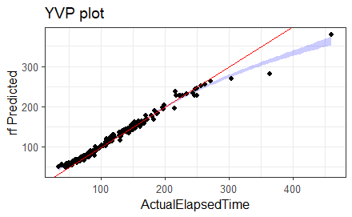

```r
rf_aug %>%
  ggplot(aes(ActualElapsedTime, .pred)) +
  stat_smooth(
    geom = "ribbon",
    method = "gam",
    aes(ymin = after_stat(y - 1.96 * se),
        ymax = after_stat(y + 1.96 * se)),
    fill = "blue",
    alpha = 0.2
  ) +
  geom_point() +
  geom_abline(aes(slope=1, intercept=0), color="red")+
  labs(y="rf Predicted", title="YVP plot") +
  theme_bw()
```

The model is a fairly good fit except for very long elapsed times.

# Variable Importance

Variable importance is interesting.The `vip` package is loaded with `mbadtools`.

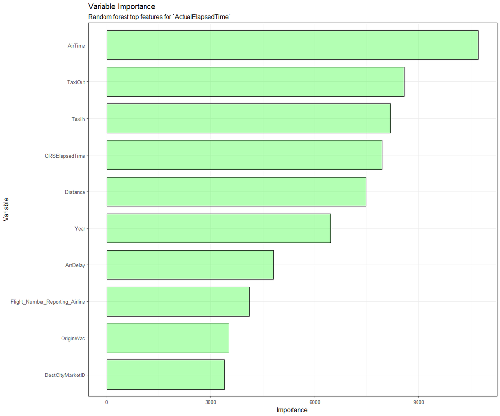

```r
rf_fit_obj <- extract_fit_parsnip(rf_fit)$fit
# variable importances
vi_rf = vi(rf_fit_obj)
# plot top featues
vi_rf %>% slice(1:10) %>%
  gg_vip(width=.8, fill="green") +
  labs(subtitle="Random forest top features for `ActualElapsedTime`")
```

# Conclusion

We have shown how to wrangle the `airlines_200` dataset with workflow preprocessing. There are lots of options for preprocessing, which you can find in the documentation for `tidymodels`.

# References

Tidymodels Website. (n.d.) (https://www.tidymodels.org/)

Kaggle (2025) Kaggle Carrier Ontime Performance. (https://www.kaggle.com/datasets/mexwell/carrier-on-time-performance-dataset)